# Practical Machine Learning-Project

Ching-Yen Shih

Sunday, April 26, 2015

## Intorduction

This project uses Weight Lifting Exercises Dataset[1] to investigate “how (well)” an activity was performed by the wearer with the set of on-body sensors. Six young health participants were asked to perform one set of 10 repetitions of the Unilateral Dumbbell Biceps Curl in five different fashions: exactly according to the specification (Class A), throwing the elbows to the front (Class B), lifting the dumbbell only halfway (Class C), lowering the dumbbell only halfway (Class D) and throwing the hips to the front (Class E).[1] The goal of this project is using data from the set of on-body sensors to predict the manner(Class A ~ class E) which the wearer did the exercise.

## Variables Selection

Overview of the raw training dataset and testing dataset

```r
training_1 <- read.csv(file = "pml-training.csv")
testing_1 <- read.csv(file = "pml-testing.csv")
dim(training_1);dim(testing_1)
```

```
## [1] 19622   160
```

```
## [1]  20 160
```

By taking a look at the data, I found there are a lot of columns with NA values or missing values. They are not useful for maching learning. Therefore, I discarded them first.

```r
df_1 <- training_1[ , ! apply( training_1 , 2 , function(x) any(is.na(x)) ) ]
df_2 <- testing_1[ , ! apply( testing_1 , 2 , function(x) any(is.na(x)) ) ]
dim(df_1);dim(df_2)
```

```
## [1] 19622    93
```

```
## [1] 20 60
```

It shows that the number of the variables remained in testing dataset is fewer than the training dataset. It’s no point to use the variables not existing in testing dataset as predictors. So I kept the variables existing in both datasets.

```r
df_3 <- df_1[,which(names(df_1) %in% names(df_2))]
dim(df_3)
```

```
## [1] 19622    59
```

Then I excluded the first seven columns which are just performer names, time records and the window numbers, they are not the values from the sensors. And I added the outcome variable “classe” into this trimmed training dataset.

```r
df_4 <- df_3[,-c(1:7)]
training <- data.frame(df_4,classe = training_1$classe) ; testing <- df_2
dim(training);dim(testing)
```

```
## [1] 19622    53
```

```
## [1] 20 60
```

## Algorithm Selection

I applied two algoithms, Classification tress and Random forest, to the training data. And picked the one with the better result by their out of sample error.

### Classification Tree

Specify the way of resampling (Cross validation, n = 10)

```r
ctrl <- trainControl(method = "cv",number = 10 )
```

Apply rpart2 in Caret to the training data.

```r
Fit_tree <- train(classe~.,method = 'rpart2',trControl = ctrl,data =training)
print(Fit_tree)
```

```
## CART
##
## 19622 samples
##    52 predictor
##     5 classes: 'A', 'B', 'C', 'D', 'E'
##
## No pre-processing
## Resampling: Cross-Validated (10 fold)
##
## Summary of sample sizes: 17658, 17659, 17660, 17661, 17660, 17660, ...
##
## Resampling results across tuning parameters:
##
##   maxdepth  Accuracy   Kappa      Accuracy SD  Kappa SD
##   1         0.3667825  0.1254520  0.005711556  0.008483914
##   4         0.4952096  0.3402251  0.010034557  0.012927524
##   5         0.5563145  0.4218911  0.010249855  0.013208210
##
## Accuracy was used to select the optimal model using  the largest value.
## The final value used for the model was maxdepth = 5.
```

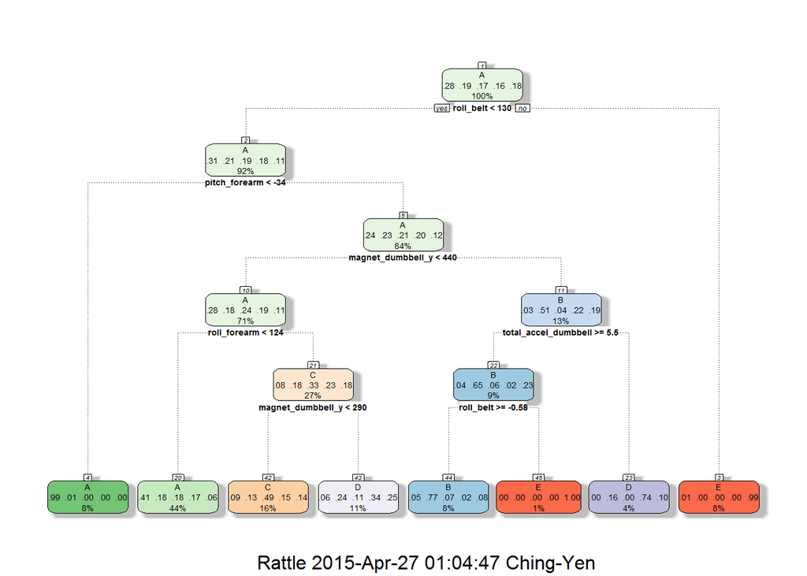

It ended up with 55.6% accuracy.

### Random Forest

In random forest, there is no need to to Cross-validation to get an unbiased estimate of the test set error.It’s estimated internally. (Refer to http://www.stat.berkeley.edu/~breiman/RandomForests/cc_home.htm#ooberr) Caret functions uses bootstrapping by default which will take a lot of computing time and it’s not necessarily needed. So I turned it off.

```r
fitControl <- trainControl(method = "none")
tgrid <- expand.grid(mtry=c(6))
Fit_rf <- train(classe~.,method = 'rf', trControl = fitControl, tuneGrid=tgrid,data=training)
print(Fit_rf$finalModel)
```

```
##
## Call:
##  randomForest(x = x, y = y, mtry = param$mtry)
##                Type of random forest: classification
##                      Number of trees: 500
## No. of variables tried at each split: 6
##
##         OOB estimate of  error rate: 0.27%
## Confusion matrix:
##      A    B    C    D    E  class.error
## A 5578    1    0    0    1 0.0003584229
## B   11 3785    1    0    0 0.0031603898
## C    0    8 3413    1    0 0.0026300409
## D    0    0   21 3193    2 0.0071517413
## E    0    0    1    6 3600 0.0019406709
```

With by default 500 trees, it produced 0.27% OOB estimate of error rate which is pretty good result and considerably better than classification tree. So I chose Random forest as the model algorithm.

## Conclusion

Apply Random forest model algorithm to testing dataset.

```r
answer_predict <- predict(Fit_rf,newdata = testing)
```

Compare the result to the correct answer with a Confusion Matrix.

```r
print(confusionMatrix(answer_Correct,answer_predict)$table)
```

```
##           Reference
## Prediction A B C D E
##          A 7 0 0 0 0
##          B 0 8 0 0 0
##          C 0 0 1 0 0
##          D 0 0 0 1 0
##          E 0 0 0 0 3
```

Get the 100% accuracy! Successfully pass the test!

## Reference

[1]Velloso, E.; Bulling, A.; Gellersen, H.; Ugulino, W.; Fuks, H. Qualitative Activity Recognition of Weight Lifting Exercises. Proceedings of 4th International Conference in Cooperation with SIGCHI (Augmented Human ’13) . Stuttgart, Germany: ACM SIGCHI, 2013.